# Predicting Exercise Quality from Activity Data

### Synopsis

With the advent of personal activity measuring devices, a large amount of such activity data can be gathered inexpensively. In this project, activity data is used to model and predict quality of exercise.

Specifically, Weight Lifting Exercise data is obtained from accelerometers on the belt, forearm, arm, and dumbell for 6 study participants to predict whether the perticipants are performing Unilateral Dumbbell Biceps Curl correctly.

This study has practical implications, as correct prediction of exercise quality can give instant feedback and correct mistakes, as well as reduce chances of exercise related injuries.

The data obtained is from the article “Qualitative Activity Recognition of Weight Lifting Exercises” [Velloso et al, SIGCHI 2013] available at: http://groupware.les.inf.puc-rio.br/work.jsf?p1=11201

In this project, the exercise data is used to predict the quality of exercise using three different prediction algorithms. The random Forest model has the highest accuracy at 99.4%.

### Basic Setup

```r
# clear everything

rm(list = ls())

# Load required packages

require(utils)
require(R.utils)
require(data.table)
require(reshape2)
require(caret)
require(kernlab)
require(randomForest)
require(gbm)
```

```r
require(survival)
require(splines)
require(ggplot2)
require(grid)
# -- set a seed

set.seed(11)
```

### Load Saved Models From File

As generating models is time intensive, save the models in a file after a run, so that they can be loaded at the time of a subsequent run.

```r
if(file.exists("saved_models.Rda")) {
    load("saved_models.Rda")
}
```

### Download Training and Test Data Files

```r
# Download training file if it does not exist in current directory

trnfl <- "pml-training.csv"
trnurl<-"https://d396qusza40orc.cloudfront.net/predmachlearn/pml-training.csv"

if (file.exists(trnfl) == FALSE) {
    download.file(trnurl, destfile = trnfl, method = "curl", quiet = TRUE)
}

# Download testing file if it does not exist in current directory

tstfl <- "pml-testing.csv"
tsturl<-"https://d396qusza40orc.cloudfront.net/predmachlearn/pml-testing.csv"

if (file.exists(tstfl) == FALSE) {
    download.file(tsturl, destfile = tstfl, method = "curl", quiet = TRUE)
}
```

### Load Training and Test Datafiles into Data Tables

```r
# Read training file into datatable.

ndt <- fread(trnfl)

# Read testfile into datatable.

sdt <- fread(tstfl)
```

### Find Columns That Are Mostly Empty (Blank or NA)

```r
# Number of rows /columns in the dataset obtained from training file.

rowCnt1 <- ndt[,.N]
colCnt1 <- length(names(ndt))

# For each column in ndt data table, count number of NA or blanks.

ndt1 <- ndt[,lapply(.SD, function(x) {is.na(x) | x == ""})][,lapply(.SD,sum)]

# Create a new data table cols with 2 columns:
# Col= column name,
# EmptyCnt = number of empty values (NA or blank) for that column

cols <- melt(ndt1, id.vars=NULL, measure.vars=c(1:colCnt1),
                variable.name="Col", value.name="EmptyCnt",
                variable.factor = FALSE)
```

### Sparse Columns

```r
empty <- cols[EmptyCnt != 0]
uniqEmpty <- empty[, unique(EmptyCnt)]
pctEmpty <- round(uniqEmpty * 100 / rowCnt1, 1)
```

All the columns that contain empty values, have a high percentage (97.9%) of values that are empty. Since so many values are empty, imputation is not going to be helpful. Instead, these columns with empty values will not be used as features (predictors).

### Columns Without Empty Values

```r
# Show the nonempty columns

(nempty <- cols[EmptyCnt == 0])
```

```
##                      Col EmptyCnt
##  1:                   V1        0
##  2:            user_name        0
##  3: raw_timestamp_part_1        0
##  4: raw_timestamp_part_2        0
##  5:       cvtd_timestamp        0
##  6:           new_window        0
##  7:           num_window        0
##  8:            roll_belt        0
##  9:           pitch_belt        0
## 10:             yaw_belt        0
## 11:     total_accel_belt        0
## 12:         gyros_belt_x        0
## 13:         gyros_belt_y        0
## 14:         gyros_belt_z        0
```

[output cut: 47 more lines]

Among the nonempty columns, classe (column 60) is the outcome we are trying to predict, so it will not be part of the feature columns. Columns 1:7 (V1, user_name, raw_timestamp_part_1, raw_timestamp_part_2, cvtd_timestamp, new_window, num_window) are not activity measurements, and so will be excluded.

```r
# Get the chosen feature columnnames into finalCols vector

finalCols <- nempty[8:59, Col]
```

### Create Data Tables with Feature Columns

```r
# Get rid of non-feature columns

ndtA <- ndt[,finalCols, with=FALSE]
sdtA <- sdt[,finalCols, with=FALSE]

# Get classe (outcome) as a vector of factors

classeA <- as.factor(ndt[,classe])
```

### Create Training and Test Datasets

```r
# Create a traindt training dataset and testdt testing dataset by using
# the createDataPartition function from the caret package.
# Change output of createDataPartition from matrix to vector.

inTrain <- as.vector(createDataPartition(y = classeA, p = 0.8, list = FALSE))

traindt <- ndtA[inTrain]
testdt <- ndtA[-inTrain]

# Similarly, partition the predicted variable classe into training and test.

trainClasse <- classeA[inTrain]
testClasse <- classeA[-inTrain]

# Remove ndt, ndtA, sdt and classeA to free up some memory.

rm(ndt, ndtA, sdt, classeA)
```

### Create Model with Training Data

A 10-fold cross-validation is used to tune the parameters for models. Three types of models are used for comparison:

- Support Vector Machines with Radial Basis Function Kernel (svmRadial)
- Stochastic Gradient Boosting (gbm)
- Random Forest (rf)

```r
# Specify training control parameters: cv = cross validation
# number = 10 (number of folds).

fitCtl <- trainControl(method = "cv", number = 10)
```

### Model 1: Support Vector Machine Model

```r
# Create a svm based model (if model does not exist)

if(!exists("svmFit")) {
    (svmFit <- train(trainClasse ~ ., data = traindt,
                 method = "svmRadial",
                 trControl = fitCtl,
                 preProc = c("center", "scale")))
}
```

[output not shown]

### Cross Validation of Support Vector Machine Model

The parameter tuned by cross validation is Cost (C).

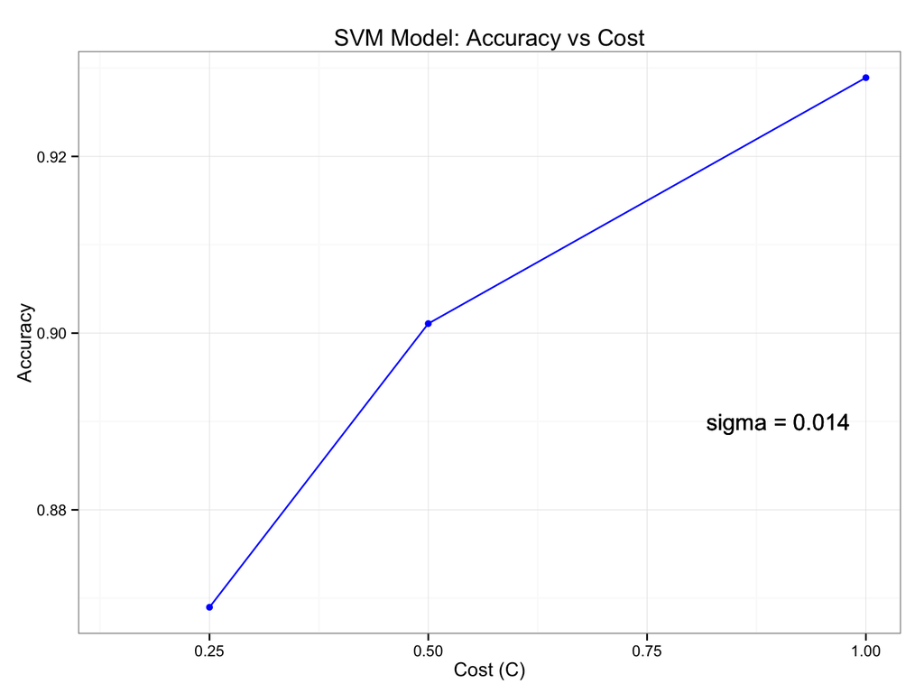

```r
# Plot1:  Accuarcy vs Cost in svm model

ggplot(svmFit$results, aes(x = C, y = Accuracy)) +
    geom_point(colour = I("blue")) + geom_line(colour = I("blue")) +
    xlab("Cost (C)") + ylab("Accuracy") +
    ggtitle("SVM Model: Accuracy vs Cost") +
    geom_text(x = 0.9, y = 0.89, label = "sigma = 0.014") +
    coord_cartesian(xlim = c(0.1, 1.04)) + theme_bw()
```

```r
# Get maximum accuracy and corresponding error in percent

svmAcc <- round(100 * max(svmFit$results$Accuracy), 1)
svmErr <- 100 - svmAcc
```

During cross validation, Cost(C) = 1 yields the highest accuracy 92.9% or cross validation error of 7.1%. With this model, the out of sample (test data) error is expected to be greater than 7.1%.

### Performance of Support Vector Machine Model with Test Data

```r
svmPred <- predict(svmFit, newdata=testdt)
confusionMatrix(svmPred, testClasse)
```

```
## Confusion Matrix and Statistics
##
##           Reference
## Prediction    A    B    C    D    E
##          A 1107   69    3    6    0
##          B    6  660   33    0    9
##          C    3   27  639   53   25
##          D    0    1    8  583   26
##          E    0    2    1    1  661
##
## Overall Statistics
##
##                Accuracy : 0.93
##                  95% CI : (0.922, 0.938)
##     No Information Rate : 0.284
##     P-Value [Acc > NIR] : <2e-16
##
##                   Kappa : 0.912
##  Mcnemar's Test P-Value : NA
##
## Statistics by Class:
##
##                      Class: A Class: B Class: C Class: D Class: E
## Sensitivity             0.992    0.870    0.934    0.907    0.917
## Specificity             0.972    0.985    0.967    0.989    0.999
## Pos Pred Value          0.934    0.932    0.855    0.943    0.994
## Neg Pred Value          0.997    0.969    0.986    0.982    0.982
## Prevalence              0.284    0.193    0.174    0.164    0.184
## Detection Rate          0.282    0.168    0.163    0.149    0.168
## Detection Prevalence    0.302    0.180    0.190    0.158    0.170
## Balanced Accuracy       0.982    0.927    0.950    0.948    0.958
```

```r
svmUnknownPred <- predict(svmFit,newdata=sdtA)
```

### Model 2: Stochastic Gradient Boosting Model

```r
# Create a gbm based model (if it does not exist).

if(!exists("gbmFit")) {
    (gbmFit <- train(trainClasse ~ ., data = traindt,
                 method = "gbm",
                 trControl = fitCtl,
                 verbose = FALSE ))
}
```

### Cross Validation of Stochastic Gradient Boosting Model

The parameters tuned by cross validation are:

- Number of Boosting Iterations (n.trees)
- Maximum Tree Depth (interaction.depth)

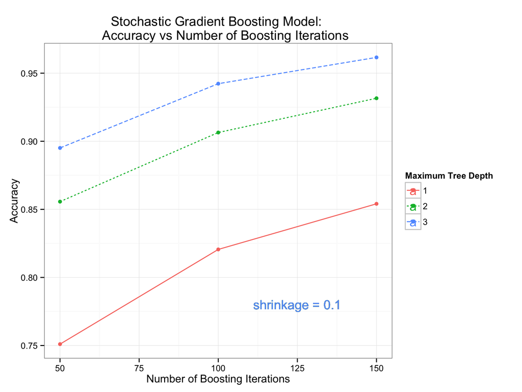

```r
# Plot1:  Accuarcy vs Cost in svm model

ggplot(gbmFit$results, aes(x = n.trees, y = Accuracy,
        group = as.factor(interaction.depth),
        linetype = as.factor(interaction.depth),
        colour = as.factor(interaction.depth))) +
    geom_point() + geom_line() +
    xlab("Number of Boosting Iterations") +
    ylab("Accuracy") + ggtitle("Stochastic Gradient Boosting Model:
    Accuracy vs Number of Boosting Iterations") +
    labs(colour = "Maximum Tree Depth", linetype = "Maximum Tree Depth") +
    geom_text(x = 125, y = 0.78, label = "shrinkage = 0.1") +
    theme_bw()
```

```r
# Get maximum accuracy and corresponding error in percent

gbmAcc <- round(100 * max(gbmFit$results$Accuracy), 1)
gbmErr <- 100 - gbmAcc
```

During cross validation, Number of Boosting Iterations = 150 and Maximum Tree Depth = 3 yields the highest accuracy 96.2% or cross validation error of 3.8%. The out of sample (test data) error is expected to be higher than 3.8%.

### Performance of Stochastic Gradient Boosting Model with Test Data

```r
gbmPred <- predict(gbmFit, newdata=testdt)

confusionMatrix(gbmPred, testClasse)
```

```
## Confusion Matrix and Statistics
##
##           Reference
## Prediction    A    B    C    D    E
##          A 1096   21    0    1    1
##          B   17  720   21    2    1
##          C    2   18  656   23    6
##          D    1    0    6  613   18
##          E    0    0    1    4  695
##
## Overall Statistics
##
##                Accuracy : 0.964
##                  95% CI : (0.957, 0.969)
##     No Information Rate : 0.284
##     P-Value [Acc > NIR] : <2e-16
##
##                   Kappa : 0.954
##  Mcnemar's Test P-Value : 0.0012
##
## Statistics by Class:
##
##                      Class: A Class: B Class: C Class: D Class: E
## Sensitivity             0.982    0.949    0.959    0.953    0.964
## Specificity             0.992    0.987    0.985    0.992    0.998
## Pos Pred Value          0.979    0.946    0.930    0.961    0.993
## Neg Pred Value          0.993    0.988    0.991    0.991    0.992
## Prevalence              0.284    0.193    0.174    0.164    0.184
## Detection Rate          0.279    0.184    0.167    0.156    0.177
## Detection Prevalence    0.285    0.194    0.180    0.163    0.178
## Balanced Accuracy       0.987    0.968    0.972    0.973    0.981
```

```r
gbmUnknownPred <- predict(gbmFit,newdata=sdtA)
```

### Model 3: Random Forest Model

```r
# Create a random forest model (if it does not exist).

if(!exists("rfFit")) {
    (rfFit <- train(trainClasse ~ ., data = traindt,
                 method = "rf",
                 trControl = fitCtl,
                 verbose = FALSE ))
}
```

### Cross Validation Performance of Random Forest Model

The parameter tuned by cross validation is:

- Number of randomly selected predictors (mtry)

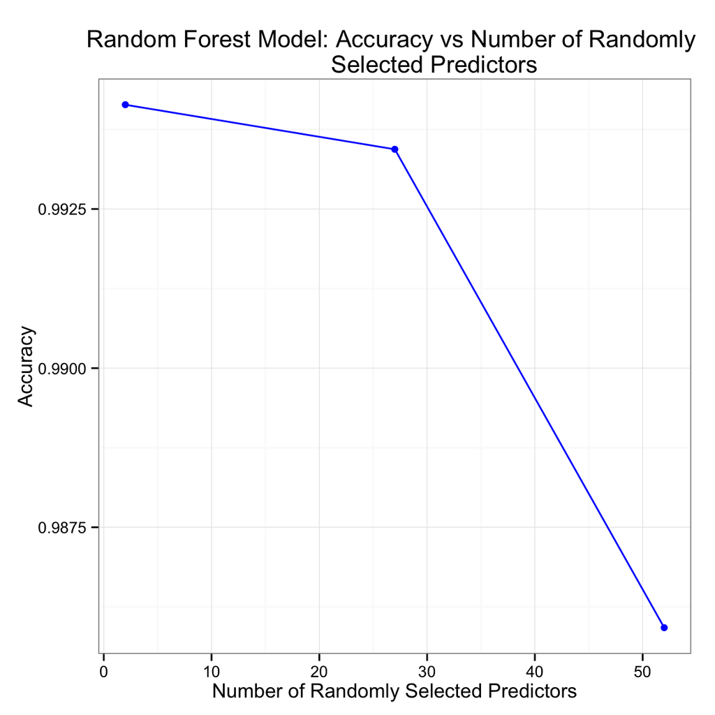

```r
# Plot3:  Accuarcy vs mtry in random Forest model.

ggplot(rfFit$results, aes(x = mtry, y = Accuracy)) +
    geom_point(colour = I("blue")) + geom_line(colour = I("blue")) +
    xlab("Number of Randomly Selected Predictors") + ylab("Accuracy") +
    ggtitle("Random Forest Model: Accuracy vs Number of Randomly
            Selected Predictors") +
    theme_bw()
```

```r
# Get maximum accuracy and corresponding error in percent

rfAcc <- round(100 * max(rfFit$results$Accuracy), 1)
rfErr <- 100 - rfAcc
```

During cross validation, Number of randomly selected predictors = 2 yields the highest accuracy 99.4% or cross validation error of 0.6%. The out of sample (test data) error is expected to be higher than 0.6%.

### Performance of Random Forest Model With Test Data

```r
rfPred <- predict(rfFit, newdata=testdt)
confusionMatrix(rfPred, testClasse)
```

```
## Confusion Matrix and Statistics
##
##           Reference
## Prediction    A    B    C    D    E
##          A 1116    5    0    0    0
##          B    0  752    5    0    0
##          C    0    2  679   10    0
##          D    0    0    0  633    2
##          E    0    0    0    0  719
##
## Overall Statistics
##
##                Accuracy : 0.994
##                  95% CI : (0.991, 0.996)
##     No Information Rate : 0.284
##     P-Value [Acc > NIR] : <2e-16
##
##                   Kappa : 0.992
##  Mcnemar's Test P-Value : NA
##
## Statistics by Class:
##
##                      Class: A Class: B Class: C Class: D Class: E
## Sensitivity             1.000    0.991    0.993    0.984    0.997
## Specificity             0.998    0.998    0.996    0.999    1.000
## Pos Pred Value          0.996    0.993    0.983    0.997    1.000
## Neg Pred Value          1.000    0.998    0.998    0.997    0.999
## Prevalence              0.284    0.193    0.174    0.164    0.184
## Detection Rate          0.284    0.192    0.173    0.161    0.183
## Detection Prevalence    0.286    0.193    0.176    0.162    0.183
## Balanced Accuracy       0.999    0.995    0.994    0.992    0.999
```

```r
rfUnknownPred <- predict(rfFit,newdata=sdtA)

data.table(svmUnknownPred, gbmUnknownPred, rfUnknownPred)
```

```
##     svmUnknownPred gbmUnknownPred rfUnknownPred
##  1:              B              C             B
##  2:              A              A             A
##  3:              B              B             B
##  4:              A              A             A
##  5:              A              A             A
##  6:              E              E             E
##  7:              D              D             D
##  8:              B              B             B
##  9:              A              A             A
## 10:              A              A             A
## 11:              B              B             B
## 12:              C              C             C
## 13:              B              B             B
## 14:              A              A             A
## 15:              E              E             E
## 16:              E              E             E
## 17:              A              A             A
## 18:              B              B             B
## 19:              B              B             B
## 20:              B              B             B
```

### Analysis

As the above data show, the Random Forest model has best accuracy (99.4% ), followed by Stochastic Gradient Boosting (96.2% ), while the Support Vector Machines with Radial Basis Function Kernel model has the worst showing (92.9% accuracy) for this dataset.

Furthermore, for the 20 rows of testdata whose classe are unknown, the predicted values are in complete agreement for Support Vector Machine model and Random Forest models. For the Stochastic Gradient Boosting model, the predicted data values are mostly in agreement with the other models, with only one exception - for problem 1, the Stochastic Gradient Boosting model predicts C whereas the other two models predict B.

Considering, however, that the Random Forest model has the highest accuracy among the three models, and the fact that the Random Forest model prediction is supported by the SVM model (majority prediction), the answer for problem 1 is chosen to be B (which is later found to be correct).

Overall, for the 20 rows of unknown Classe, both Random Forest and SVM models have 100% accurate predictions, which is slightly better than expected. The Stochastic Gradient Boosting model has 95% accuracy, which is in expected accuracy range for out of sample data.

### Write Answers to Individual Files

```r
ans <- rfUnknownPred

for(i in 1:length(ans)){
    filename = paste0("problem_id_",i,".txt")
    write.table(ans[i],file=filename,quote=FALSE,row.names=FALSE,
                col.names=FALSE)
  }
```

### Save Models to a File

```r
# Save to file if it does not exist already.

if(!file.exists("saved_models.Rda")) {
    save( rfFit, gbmFit, svmFit, file = "saved_models.Rda")
}
```